# Recommendation for investor who want to invest a airline company

Project 3

500425334

University of Sydney | DATA1001 | April 2020

# 1 Recommendation

# 2 Evidence

## 2.1 Limitation

All of these samples are relevant to Australia, it is hard to know operating status in other country, so there is a selection bais.

## 2.2 IDA

```r
# International Airlines operating from Australia
flights = read.csv("http://www.maths.usyd.edu.au/u/UG/JM/DATA1001/r/current/projects/2020data/flights.csv")
library(plyr)
library(tidyverse)
## Quick snapshot
dim(flights)
```

```
## [1] 89312    15
```

```r
str(flights)
```

```
## 'data.frame':    89312 obs. of  15 variables:
##  $ Month             : int  37865 37865 37865 37865 37865 37865 37865 37865 37865 37865 ...
##  $ In_Out            : Factor w/ 2 levels "I","O": 1 1 1 1 1 1 1 1 1 1 ...
##  $ Australian_City   : Factor w/ 14 levels "Adelaide","Brisbane",..: 1 1 1 1 1 1 2 2 2 2 ...
##  $ International_City: Factor w/ 99 levels "Abu Dhabi","Apia",..: 17 32 40 83 83 83 3 3 3 3 ...
##  $ Airline           : Factor w/ 84 levels "Aerolineas Argentinas",..: 37 25 52 60 60 68 9 36 37 52 ...
##  $ Route             : Factor w/ 1152 levels "ADL-AKL","ADL-CAN",..: 259 335 396 820 821 800 16 16 19 21 ...
##  $ Port_Country      : Factor w/ 46 levels "Argentina","Austria",..: 16 14 21 32 32 32 26 26 26 26 ...
##  $ Port_Region       : Factor w/ 10 levels "Africa","Europe",..: 10 6 10 10 10 10 7 7 7 7 ...
##  $ Service_Country   : Factor w/ 44 levels "Argentina","Austria",..: 16 14 21 30 30 30 25 25 25 25 ...
##  $ Service_Region    : Factor w/ 10 levels "Africa","Europe",..: 10 6 10 10 10 10 7 7 7 7 ...
##  $ Stops             : int  0 0 0 1 1 0 0 0 0 0 ...
##  $ All_Flights       : int  13 8 17 4 9 12 36 18 8 14 ...
##  $ Max_Seats         : int  3809 2008 4726 908 2038 3876 12624 2556 2296 5404 ...
##  $ Year              : int  2003 2003 2003 2003 2003 2003 2003 2003 2003 2003 ...
##  $ Month_num         : int  9 9 9 9 9 9 9 9 9 9 ...
```

## 2.3 Which airline company held the most routes?

```r
t1 = table(flights$Airline[flights$Stops==0])
head(sort(t1, decreasing = TRUE), 10)
```

```
##
##             Qantas Airways                    Jetstar
##                      13858                       8517
##           Virgin Australia            Air New Zealand
##                       6791                       5760
##                   Emirates     Cathay Pacific Airways
##                       3891                       2129
##           Garuda Indonesia          Malaysia Airlines
##                       1933                       1838
##         Singapore Airlines Thai Airways International
##                       1650                       1493
```

## 2.4 The number of passengers per airline per year from 2003 to 2018

```r
flights_seat <- flights[flights$Stops==0,] %>% mutate(All_Flights*Max_Seats)
data2 = aggregate(All_Flights * Max_Seats ~ Airline + Year, data = flights_seat, sum)
colnames(data2) <- c("Airline", "Year", "All_seat")
head(data2[order(-data2$All_seat),], 10)
```

```
##                Airline Year  All_seat
## 739 Singapore Airlines 2017 470280959
## 682 Singapore Airlines 2016 430817355
## 626 Singapore Airlines 2015 405126775
## 573 Singapore Airlines 2014 404092433
## 732     Qantas Airways 2017 392661368
## 524 Singapore Airlines 2013 377364474
## 676     Qantas Airways 2016 350853870
## 173     Qantas Airways 2006 345323188
## 475 Singapore Airlines 2012 331359774
## 518     Qantas Airways 2013 326093489
```

```r
head(data2[order(data2$All_seat),], 10)
```

```
##                        Airline Year All_seat
## 607            Hainan Airlines 2015     4500
## 224                   Silk Air 2007     4544
## 295                   Airnorth 2009     5472
## 78       Royal Tongan Airlines 2004     5976
## 29  Merpati Nusantara Airlines 2003     6400
## 71  Merpati Nusantara Airlines 2004     9520
## 30              Nauru Airlines 2003    13200
## 121 Merpati Nusantara Airlines 2005    17400
## 131                   Tigerair 2005    17640
## 73         Norfolk Jet Express 2004    19456
```

In 2017, there are 470 millions people chose Singapore Airlines, which was the most in the past 15 years, and in 2015, hainan airlines only have 4500 passengers, which was the least in past 15 years.

## 2.5 Which month does the largest number of people travel?

```r
#into Australia
table(flights$Month_num[flights$In_Out=="I"])
```

```
##
##    1    2    3    4    5    6    7    8    9   10   11   12
## 3765 3698 4281 3352 3401 4106 3476 3372 4340 3384 3336 4361
```

```r
#out of Australia
table(flights$Month_num[flights$In_Out=="O"])
```

```
##
##    1    2    3    4    5    6    7    8    9   10   11   12
## 3780 3680 4327 3340 3293 3914 3408 3352 4246 3358 3336 4406
```

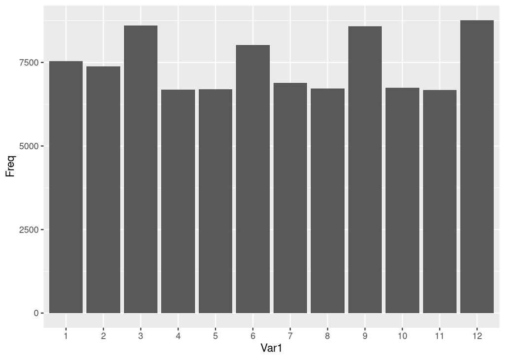

```r
#total
table(flights$Month_num) %>% as.data.frame %>% ggplot(aes(x = Var1, y = Freq)) + geom_histogram(stat = "identity")
```

## 2.6 Which company’s number of passenger ascends the fastest?

```r
t1DataFrame = as.data.frame(t1)
ratio = lapply(t1DataFrame$Var1, function(x){lm(data2$All_seat[data2$Airline == x] ~ data2$Year[data2$Airline == x])$coeff[[2]]})
ratio_unlist = unlist(ratio)
t1DataFrame$ratio <- ratio_unlist
head(t1DataFrame[order(t1DataFrame$ratio, decreasing = TRUE), ], 10)
```

```
##                       Var1  Freq    ratio
## 68      Singapore Airlines  1650 19791655
## 60          Qantas Airways 13858  9838878
## 32                Emirates  3891  8869231
## 25  Cathay Pacific Airways  2129  8768998
## 9          Air New Zealand  5760  7729544
## 14               AirAsia X   971  7575001
## 82        Virgin Australia  6791  7002711
## 46                 Jetstar  8517  5771706
## 33          Etihad Airways   830  5095022
## 29 China Southern Airlines  1090  4808927
```

Singapore airlines’ number of passengers increase 19 million per year in average, far more than other company.

## 2.7 How many route and seats did Singapore airlines operate in total?

```r
sum(flights_seat$`All_Flights * Max_Seats`[flights_seat$Airline=="Singapore Airlines"])
```

```
## [1] 4375118976
```

```r
sum(flights_seat$Airline=="Singapore Airlines")
```

```
## [1] 1650
```

```r
sum(flights_seat$`All_Flights * Max_Seats`)/84
```

```
## [1] 273819487
```

## 2.8 What is the increase in the number of Singapore airlines’s passenger from 2003 and 2018, and the prediction of the number in 2019

[figure not shown]

```r
sinData = data2[data2$Airline=="Singapore Airlines",]
ggplot(sinData, aes(Year, All_seat/10000)) + geom_point() + ggtitle("Number of seat operate by Singapore Airlines from 2003 to 2018") + ylab("seat (in thousands)") + geom_smooth(method='lm', se=FALSE)
```

```r
l = lm(sinData$All_seat ~ sinData$Year)
l
```

```
##
## Call:
## lm(formula = sinData$All_seat ~ sinData$Year)
##
## Coefficients:
##  (Intercept)  sinData$Year
##   -3.952e+10     1.979e+07
```

```r
cor(sinData$All_seat, sinData$Year)
```

```
## [1] 0.6930404
```

```r
2019 * l$coeff[[2]] + l$coeff[[1]]
```

```
## [1] 441674007
```

# 3 Other Evidence

*Max 100 words: Cites at least 2 related articles (research or media) that add weight, subtlety or limitations to the evidence from data.*

https://www.anna.aero/ suggest that Singapore airlines sees steady growth, after a significant fall in traffic in 2009, the airline has gradually recovered its passenger numbers following eight consecutive years of growth., and it opened a new market in Sweden in 2017.

M Rahman suggest that Singapore Airlines is a world-renowned airline, One of the biggest strengths of SIA is its position in the European markets. However, Over reliance on international traffic is a weakness of Singapore Airlines. But overall, the airline has opportunities to increase flight frequencies in its existing markets.

# 4 Reference

Singapore Airlines sees steady growth; Jakarta is largest link, Australia is biggest international market, Retrieved 30 April, 2018, from https://www.anna.aero/2018/04/30/singapore-airlines-sees-steady-growth-jakarta-is-largest-link-australia-is-biggest-international-market/

M Rahman (02 January 2020), SWOT analysis of Singapore Airlines, from https://howandwhat.net/swot-analysis-singapore-airlines-singapore-airlines-swot-analysis/

#Data Science Reflection Technique in DATA1001 help me to organize data, I can turn it into numeric or graphic information which is easier to read, moreover, I can use this method to predict value in the future.